# Second Assignment

## Image Processing

### 4th CSE 2020

| Name | ID | Email |
| --- | --- | --- |
| Baher Abdelfatah Atia Abdelfatah | 1500405 | baherbehooo@gmail.com |
| Eslam Tarek Fawzy | 1500269 | eslamsolari1996@email.com |

# 1 Dilation

#### ( 1 mark)

Dilation is one of the basic operators in the area of morphology. The basic effect of the operator on a binary image is to gradually expand the region boundary of the foreground Pixels.

```python
import cv2
import numpy as np
import matplotlib.pyplot as plt
import matplotlib.image as mpimg
%matplotlib inline
```

1. In this problem, read the ‘square-circle.png’. Use the dilation operation on this image with two different structuring elements (square and circle). This size of structuring element is of your choice. Plot results with title square-circle-1 and square-circle-2. Compare and contrast your results. Explain your Observations. (0.5 mark)

[figure not shown]

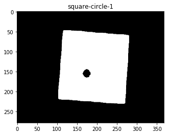

```python
# TODO: use first structuring element
img = plt.imread('Square-circle.png', 0)
kernel = cv2.getStructuringElement(cv2.MORPH_RECT,(11,11))
img_dilation = cv2.dilate(img, kernel, iterations=1)
plt.title('square-circle-1')
plt.imshow(img_dilation)
```

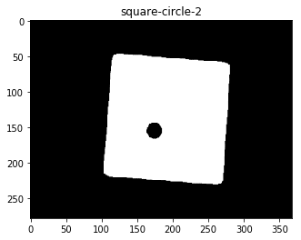

```python
# TODO: use second structuring element
img = plt.imread('Square-circle.png', 0)
kernel = cv2.getStructuringElement(cv2.MORPH_ELLIPSE,(11,11))
img_dilation = cv2.dilate(img, kernel, iterations=1)
plt.title('square-circle-2')
plt.imshow(img_dilation)
```

*Observation:*

##### write your observation here.

Both square and circle structure elements increase the white region in the image and decreases the size of the black hole for circle structure element the black hole is smooth as both the hole and the structure element are circles for square structure element the black hole has rough edges as the square structure element as straight edges

2- Edge detection can be accomplished using dilation in conjunction with other operations. There are different methods. Describe how you perform edge detection using dilation. Use the lady.png for this operation. Plot your result with title lady-edge. (0.5 mark)

[figure not shown]

[figure not shown]

```python
#TODO : use suitable morphological operations to apply edge detection.
img = plt.imread('lady.png', 0)
img_canny = cv2.Canny(img,100,200)
kernel = cv2.getStructuringElement(cv2.MORPH_CROSS,(3,3))
img_dilation = cv2.dilate(img_canny, kernel, iterations=1)
plt.title('lady-edge')
plt.imshow(img_dilation,cmap = 'gray')
```

*Description:* This method implies that the first derivative operator of edge detection like canny with the combination of morphology. So the morphological operators like dilation are used efficiently with edge detection operator to find the different edges.

# 2 Erosion

#### ( 1 mark)

The basic effect of the erosion operator on a binary image is to erode away the boundaries of regions of foreground pixels. Thus the areas of the foreground pixel shrink in size and holes within those areas become larger.

3- Apply the erosion technique to ‘circle-square.png’. Use two different structuring elements (circle and square). Plot the image with title circle-square-erode . Compare and contrast your results. Explain your observation. (0.5 mark)

[figure not shown]

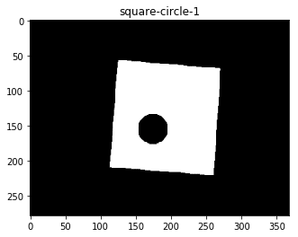

```python
# TODO: use first structuring element
img = plt.imread('Square-circle.png', 0)
kernel = cv2.getStructuringElement(cv2.MORPH_ELLIPSE,(11,11))
img_erosion = cv2.erode(img, kernel, iterations=1)
plt.title('square-circle-1')
plt.imshow(img_erosion)
```

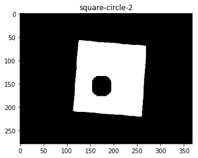

```python
# TODO: use second structuring element
img = plt.imread('Square-circle.png', 0)
kernel = cv2.getStructuringElement(cv2.MORPH_RECT,(11,11))
img_erosion = cv2.erode(img, kernel, iterations=1)
plt.title('square-circle-2')
plt.imshow(img_erosion)
```

*observation:* Both square and circle structure elements decrease the white region in the image and increases the size of the black hole for circle structure element the black hole is smooth as both the hole and the structure element are circles for square structure element the black hole has rough edges(squarish shape) as the square structure element as straight edges

4- The image shows a number of dark disks against a light background. Do a thresholding of this image and then use the erosion operation to display the circles distinctly in the image. Plot your image with title circle-erode. (0.5 mark)

[figure not shown]

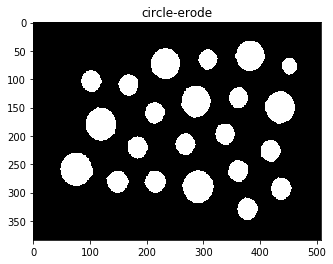

```python
# Write your code here
img = cv2.imread('Circle.png',0)
ret,thresh1 = cv2.threshold(img,127,255,cv2.THRESH_BINARY_INV)
kernel = cv2.getStructuringElement(cv2.MORPH_ELLIPSE,(30,30))
img_erosion = cv2.erode(thresh1, kernel, iterations=1)
plt.title('circle-erode')
plt.imshow(img_erosion,cmap = 'gray')
```

# 3 Opening and Closing

### ( 3 marks)

These are operations that are derived from the fundamental operations of erosion and dilation. The basic effect of an opening is like erosion in that it tends to remove some of the foreground (bright) pixels from the edges of regions of foreground pixels. The exact operation is determined by the structural element only. Closing is similar in some ways to dilation, in that it tends to enlarge the boundaries of the foreground regions in an image

5- In this section you will be separating out various objects from the images using the opening function. For the given image Circle_and_Lines.png, use the opening technique with the appropriate structuring element. ( 2 marks)

[figure not shown]

(a) Your mission is to separate the circles from the lines. Plot your image as circle and line. The circle_png image should contain only circles, and the line.png image should contain only lines. Explain the structural element you have used. If you have experimented with other structural elements, describe your results and observations. What are the drawbacks or limitations of this method? Compare and contrast with the previous methods you have implemented. Apply opening to the same image with the same structural element of different sizes. How the sizes of the structuring elements affect the results. ( 1 mark)

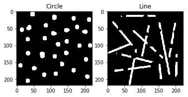

```python
## TODO: Seperate circles and lines
img = cv2.imread('Circle_and_Lines.png',0)
kernel = cv2.getStructuringElement(cv2.MORPH_ELLIPSE,(11,11))
circle = cv2.morphologyEx(img, cv2.MORPH_OPEN, kernel)
line = img - circle
kernel = cv2.getStructuringElement(cv2.MORPH_RECT,(2,2))
line = cv2.morphologyEx(line, cv2.MORPH_OPEN, kernel)
fig = plt.figure()
ax1 = fig.add_subplot(1,2,1)
ax1.title.set_text('Circle')
ax1.imshow(circle,cmap = 'gray')
ax2 = fig.add_subplot(1,2,2)
ax2.title.set_text('Line')
ax2.imshow(line,cmap = 'gray')
```

*Description:*

##### Answer the questions here.

for detecing circles I used circle shaped kernel for opening for detecting lines first i subtracted the circles from original image then used a rectangular shaped kernel for opening Increasing the size of kernel too much results in completely black image Limitations: lines are cutted

(b) Develop an algorithm; using the appropriate morphological filters, to count how many circles and how many lines are there in Circle_and_lines.png (via circles.png. and lines.png), “Label each item in the picture with a distinct integer”. Discuss your algorithm briefly, and document your code and your results in the report. ( 1 mark)

##### Hint:

use connected components to count the objects.

To label: cv2.putText, parameters Text and Center point (from connected components )

```
No. of Circles is : 30
Number of lines: 12
```

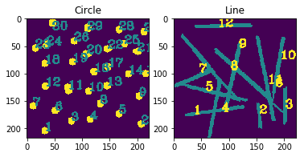

```python
# Write your code here
from skimage import measure
circles = measure.label(circle)
print("No. of Circles is :", circles.max())
ret, thresh = cv2.threshold(line, 80, 255, cv2.THRESH_BINARY_INV)
kernel3 = cv2.getStructuringElement(cv2.MORPH_RECT, (9,9))
img_dilatio = cv2.dilate(line, kernel3)
contours, hierarchy = cv2.findContours(img_dilatio, cv2.RETR_EXTERNAL, cv2.CHAIN_APPROX_SIMPLE)
print('Number of lines:', len(contours))
_, binary_image = cv2.threshold(img_dilatio, 0, 255, cv2.THRESH_BINARY_INV)
n_labels, labels, stats, centroids = cv2.connectedComponentsWithStats(binary_image, connectivity=4)

font = cv2.FONT_HERSHEY_COMPLEX

fig = plt.figure()
count=1
circle_count = circle.copy()
contours, hierarchy = cv2.findContours(circle_count, cv2.RETR_EXTERNAL, cv2.CHAIN_APPROX_SIMPLE)
for cnt in contours :
    approx = cv2.approxPolyDP(cnt, 0.009 * cv2.arcLength(cnt, True), True)
    string = str(count)
    M = cv2.moments(cnt)
    # Centroid
    cx = int(M['m10']/M['m00'])
    cy = int(M['m01']/M['m00'])
    cv2.putText(circle_count, string, (cx,max(cy,20)),font, 0.7, (120, 255, 21),2)
    count = count + 1
ax1 = fig.add_subplot(1,2,1)
ax1.title.set_text('Circle')
ax1.imshow(circle_count)

# Going through every contours found in the image.
count=1
lines_count = line.copy()

# Convert the img to grayscale
gray = lines_count
edges=gray
lines = cv2.HoughLinesP(edges,1,np.pi/180,30,minLineLength=20,maxLineGap=0)
#lines = cv2.HoughLinesP(edges,2,np.pi/180,100,minLineLength=10,maxLineGap=20)
black_image = np.zeros(lines_count.shape, dtype = "uint8")
black_image_2 = np.zeros(lines_count.shape, dtype = "uint8")

for line1 in lines:
    x1,y1,x2,y2 = line1[0]
    cv2.line(black_image,(x1,y1),(x2,y2),(120, 120, 120),1)
lines = cv2.HoughLinesP(edges,2,np.pi/180,30,minLineLength=40,maxLineGap=20)


for line1 in lines:
    x1,y1,x2,y2 = line1[0]
    cv2.line(black_image_2,(x1,y1),(x2,y2),(120, 120, 120),2)



kernel = cv2.getStructuringElement(cv2.MORPH_RECT,(2,2))
black_image = cv2.dilate(black_image, kernel, iterations=3)
kernel = cv2.getStructuringElement(cv2.MORPH_RECT,(2,2))
black_image = cv2.erode(black_image, kernel, iterations=2)
kernel = cv2.getStructuringElement(cv2.MORPH_RECT,(1,1))
black_image = cv2.erode(black_image, kernel, iterations=1)

#kernel = cv2.getStructuringElement(cv2.MORPH_RECT,(2,2))
#black_image = cv2.morphologyEx(black_image, cv2.MORPH_OPEN, kernel)

count =1
contours, hierarchy = cv2.findContours(black_image, cv2.RETR_EXTERNAL, cv2.CHAIN_APPROX_SIMPLE)
for cnt in contours :
    approx = cv2.approxPolyDP(cnt, 0.000005 * cv2.arcLength(cnt, True), True)
    string = str(count)
    M = cv2.moments(cnt)
    # Centroid
    cx = int(M['m10']/(M['m00']+1))
    cy = int(M['m01']/(M['m00']+1))
    cv2.putText(black_image_2, string, (cx,cy),font, 0.7, (255, 255, 255),2)
    count = count +1


ax2 = fig.add_subplot(1,2,2)
ax2.title.set_text('Line')
ax2.imshow(black_image_2)
```

6- Design an image processing pipeline for calculating the money and highlighting the coins available in the following image. Given that the large coin is 50, and the small one is 25. ( 1 mark)

[figure not shown]

```
Money = 400
```

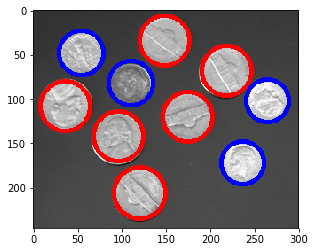

```python
## Write your code here
money=0
image = cv2.imread('coins.png')
output = image.copy()
gray = cv2.cvtColor(image, cv2.COLOR_BGR2GRAY)
gray_blurred = cv2.blur(gray, (9, 9))
# detect circles in the image
circles = cv2.HoughCircles(gray_blurred,cv2.HOUGH_GRADIENT, 1, 20, param1 = 50, param2 = 30, minRadius = 1, maxRadius = 40)
# ensure at least some circles were found
if circles is not None:
    # convert the (x, y) coordinates and radius of the circles to integers
    circles = np.round(circles[0, :]).astype("int")
    # loop over the (x, y) coordinates and radius of the circles
    for (x, y, r) in circles:
        # draw the circle in the output image, then draw a rectangle
        # corresponding to the center of the circle
        if r < 26 :
            cv2.circle(output, (x, y), r, (0, 0, 255), 4)
            money += 25
        else:
            cv2.circle(output, (x, y), r, (255, 0, 0), 4)
            money += 50
    # show the output image
    plt.imshow(output)
    print("Money =" ,money)
```

How could you generalize it to work with this?

[figure not shown]

[figure not shown]

```python
## Write your code here
image = cv2.imread('coins_color.jpeg')
output = image.copy()
gray = cv2.cvtColor(image, cv2.COLOR_BGR2GRAY)
gray_blurred = cv2.blur(gray, (11, 11))
# detect circles in the image
circles = cv2.HoughCircles(gray_blurred,cv2.HOUGH_GRADIENT, 1, 20, param1 = 50, param2 = 30, minRadius = 1, maxRadius = 40)
# ensure at least some circles were found
if circles is not None:
    # convert the (x, y) coordinates and radius of the circles to integers
    circles = np.round(circles[0, :]).astype("int")
    # loop over the (x, y) coordinates and radius of the circles
    for (x, y, r) in circles:
        # draw the circle in the output image, then draw a rectangle
        # corresponding to the center of the circle
        if r < 18 :
            cv2.circle(output, (x, y), r, (0, 0, 255), 4)
        elif r >= 18 and r < 25:
            cv2.circle(output, (x, y), r, (0, 255, 0), 4)
        else:
            cv2.circle(output, (x, y), r, (255, 0, 0), 4)
    # show the output image
    plt.imshow(output)
```

# Bonus

### ( 1 bonus mark)

7- Propose a pipeline to replace the morning background of the left image with the night background of the right image.

[figure not shown]

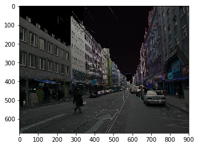

```python
## Write your code here

img1 = cv2.imread('morning.jpg')
mask_1 = np.zeros(img1.shape[:2],np.uint8)
img2 = cv2.imread('evening.jpg')
mask_2 = np.zeros(img2.shape[:2],np.uint8)
bgdModel = np.zeros((1,65),np.float64)
fgdModel = np.zeros((1,65),np.float64)
width = int(img1.shape[1])
height = int(img1.shape[0])
rect_1 = (0,1,width,height)
# this modifies mask
cv2.grabCut(img1,mask_1,rect_1,bgdModel,fgdModel,5,cv2.GC_INIT_WITH_RECT)

rect_2 = (300,0,400,500)
cv2.grabCut(img2,mask_2,rect_2,bgdModel,fgdModel,5,cv2.GC_INIT_WITH_RECT)

# If mask==2 or mask== 1, mask2 get 0, other wise it gets 1 as 'uint8' type.
mask2_1 = np.where((mask_1==2)|(mask_1==0),0,1).astype('uint8')
mask2_2 = np.where((mask_2==2)|(mask_2==0),0,1).astype('uint8')
# adding additional dimension for rgb to the mask, by default it gets 1
# multiply it with input image to get the segmented image
img_cut_1 = img1*mask2_1[:,:,np.newaxis]
img_cut_2 = img2*mask2_2[:,:,np.newaxis]
alpha=0.3
beta = (1.0 - alpha)
width = int(img_cut_1.shape[1])
height = int(img_cut_1.shape[0])
dim = (width, height)
img_cut_2 = cv2.resize(img_cut_2, dim, interpolation = cv2.INTER_AREA)
dst = cv2.addWeighted(img_cut_1, 0.7, img_cut_2, 0.3, 0.0)
plt.imshow(dst)
```

### ( 1 bonus mark)

8- You need to detect Thumbs up! First detect contours from thumbs_up_down.jpg

[figure not shown]

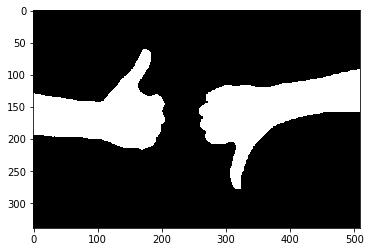

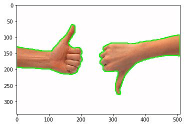

```python
# TODO detect contors for the hands
image = cv2.imread("thumbs_up_down.jpg")
# convert to RGB
image = cv2.cvtColor(image, cv2.COLOR_BGR2RGB)
# convert to grayscale
gray = cv2.cvtColor(image, cv2.COLOR_RGB2GRAY)
# create a binary thresholded image
_, binary = cv2.threshold(gray, 225, 255, cv2.THRESH_BINARY_INV)
# show it
plt.imshow(binary, cmap="gray")
plt.show()
contours, hierarchy = cv2.findContours(binary, cv2.RETR_TREE, cv2.CHAIN_APPROX_SIMPLE)
# draw all contours
image = cv2.drawContours(image, contours, -1, (0, 255, 0), 2)
# show the image with the drawn contours
plt.imshow(image)
plt.show()
```

## Contour Features

Every contour has a number of features that you can calculate, including the area of the contour, it's orientation (the direction that most of the contour is pointing in), it's perimeter, and many other properties outlined in OpenCV documentation, here. https://opencv-python-tutroals.readthedocs.io/en/latest/py_tutorials/py_imgproc/py_contours/py_contour_properties/py_contour_properties.html

In the next cell, you'll be asked to identify the orientations of both the left and right hand contours. The orientation should give you an idea of which hand has its thumb up and which one has its thumb down!

Orientation The orientation of an object is the angle at which an object is directed. To find the angle of a contour, you should first find an ellipse that fits the contour and then extract the angle from that shape.

*Fit an ellipse to a contour and extract the angle from that ellipse*

#### (x,y), (MA,ma), angle = cv2.fitEllipse(selected_contour)

##### Orientation values

These orientation values are in degrees measured from the x-axis. A value of zero means a flat line, and a value of 90 means that a contour is pointing straight up!

So, the orientation angles that you calculated for each contour should be able to tell us something about the general position of the hand. The hand with it's thumb up, should have a higher (closer to 90 degrees) orientation than the hand with it's thumb down.

### TODO: Find the orientation of each contour

```python
## TODO: Complete this function so that
## it returns the orientations of a list of contours
## The list should be in the same order as the contours
## i.e. the first angle should be the orientation of the first contour
def orientations(contours):
    """
    Orientation
    :param contours: a list of contours
    :return: angles, the orientations of the contours
    """
    # Create an empty list to store the angles in
    # Tip: Use angles.append(value) to add values to this list
    angles = []
    for cnt in contours:
        (x,y), (MA,ma), angle = cv2.fitEllipse(cnt)
        angles.append(angle)
    return angles


# ---------------------------------------------------------- #
# Print out the orientation values
angles = orientations(contours)
print('Angles of each contour (in degrees): ' + str(angles))
```

```
Angles of each contour (in degrees): [61.35833740234375, 82.27550506591797]
```

## Bounding Rectangle

In the next cell, you'll be asked to find the bounding rectangle around the left hand contour, which has its thumb up, then use that bounding rectangle to crop the image and better focus on that one hand!

*Find the bounding rectangle of a selected contour*

### x,y,w,h = cv2.boundingRect(selected_contour)

*Draw the bounding rectangle as a purple box*

#### box_image = cv2.rectangle(contours_image, (x,y), (x+w,y+h), (200,0,200),2)

And to crop the image, select the correct width and height of the image to include.

*Crop using the dimensions of the bounding rectangle (x, y, w, h)

#### cropped_image = image[y: y + h, x: x + w]

### TODO: Crop the image around a contour

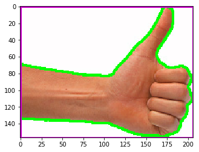

```python
## TODO: Complete this function so that
## it returns a new, cropped version of the original image
def left_hand_crop(image, selected_contour):
    """
    Left hand crop
    :param image: the original image
    :param selectec_contour: the contour that will be used for cropping
    :return: cropped_image, the cropped image around the left hand
    """

    ## TODO: Detect the bounding rectangle of the left hand contour
    x,y,w,h = cv2.boundingRect(selected_contour)
    box_image = cv2.rectangle(image, (x,y), (x+w,y+h), (200,0,200),2)
    ## TODO: Crop the image using the dimensions of the bounding rectangle
    # Make a copy of the image to crop
    cropped_image = np.copy(image)
    cropped_image = image[y: y + h, x: x + w]
    return cropped_image


## TODO: Select the left hand contour from the list
## Replace this value
selected_contour = contours[1]


# ---------------------------------------------------------- #
# If you've selected a contour
if(selected_contour is not None):
    # Call the crop function with that contour passed in as a parameter
    cropped_image = left_hand_crop(image, selected_contour)
    plt.imshow(cropped_image)
```

# Congratulations! You have finished your last assignment \o/